# STAT 184 Final Project

##### GRAPH 4: This graph is a bar graph of net sentiment score by year with the bars a different color across decade. I used the right_join function to join the data frame filtered_words_final which contains the filtered tidy data and the data set sentiments. To recode the sentiment values (positive and negative) into 1 for positive and 0 for negative, I created a variable s_score using the mutate function and calculated the net_score. The graph is representing the net sentiment score by year but the x-axis had been modified to depict a decade using the scale_x_discrete function.

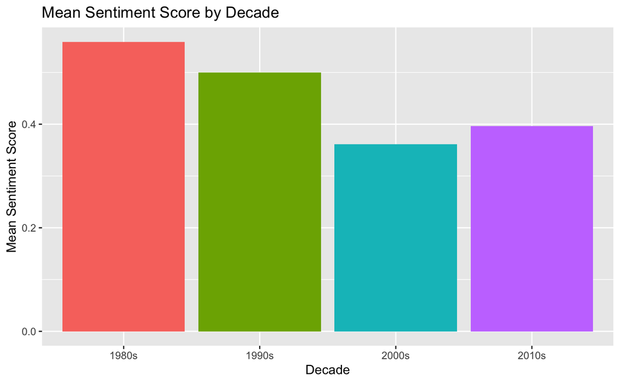

```r
# creating another table with the mean sentiment score per decade
sentiment_score2<-
  filtered_words_final%>%
  select(decade,word,year)%>%
  right_join(sentiments, by="word")%>%
  mutate(s_score= ifelse(sentiment=="positive",1,0))%>%
  group_by(decade,)%>%
  summarise(mean_score=mean(s_score))%>%
  na.omit(sentiment_score1)
# plot for the mean sentiment score by decade
ggplot(sentiment_score2) +
 aes(x = decade, fill = decade, weight = mean_score) +
 geom_bar() +
 scale_fill_hue() +
 labs(x = "Decade", y = "Mean Sentiment Score", title = "Mean Sentiment Score by Decade ") +
 theme_gray() +
 theme(legend.position = "none")
```

##### GRAPH 5: A bar graph of mean sentiment score per decade without a legend. Again I joined the two data sets, filtered_words_final and sentiments to find the mean sentiment score by decade and greated a labled bar graph with each decade having a different colour.

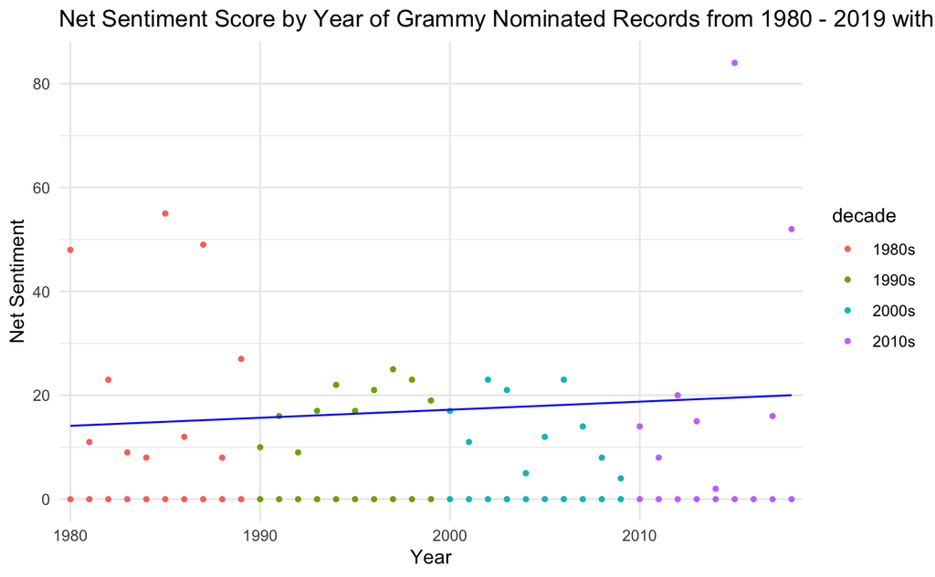

```r
# plot and regression line for the net sentiment score by year of the Grammy nominated records from 1980-2019 with linear model fit
ggplot(data=sentiment_score1,aes(x=year, y=net_score)) +
   geom_point(aes(color= decade), size=1)+
   geom_smooth(na.rm = TRUE, fullrange= TRUE, aes(group=1),colour="blue", size=0.5, se=FALSE)+
  labs(title="Net Sentiment Score by Year of Grammy Nominated Records from 1980 - 2019 with Linear Model Fit", x="Year", y="Net Sentiment")+
  scale_x_discrete(breaks=c("1980","1990","2000","2010","2020"))+
   theme_minimal()
```

##### GRAPH 6: Point graph of net sentiment scores versus year with a single regression line and the point colour representing the decade. this was a relatively simple graph to create because I used the already calculated net_score for the sentiments. In all this project was not just a great learning experience but also taugh me how to keep trying until you get the solution you need.